# Análisis de los Hábitos Digitales y la Salud Mental

Aldair Yauri Altamirano

2025-06-13

# Definición del Proyecto

Este conjunto de datos sintéticos está diseñado para simular el comportamiento digital de jóvenes pertenecientes a la Generación Z y explorar sus posibles efectos sobre la salud mental. Se basa en la generación artificial de patrones estadísticos que imitan comportamientos reales sin comprometer la privacidad.

# Objetivo General

Analizar la relación entre los hábitos digitales y la salud mental en jóvenes de la Generación Z, mediante la identificación de patrones, correlaciones y predictores significativos que permitan generar conciencia y orientar futuras intervenciones en el ámbito de la salud pública.

# Diccionario de Variables

- `screen_time_hours`: Tiempo total diario frente a pantallas digitales (en horas).
- `social_media_platforms_used`: Número de plataformas de redes sociales utilizadas al día.
- `hours_on_TikTok`: Tiempo promedio diario dedicado exclusivamente a TikTok (en horas).
- `sleep_hours`: Número promedio de horas de sueño por día.
- `stress_level`: Nivel de estrés percibido (escala de 1 a 10).
- `mood_score`: Nivel de estado de ánimo (escala de 1 a 10, donde un valor mayor indica mejor estado de ánimo).

# Fuente de los Datos

Plataforma: Kaggle  
URL: https://www.kaggle.com/datasets/abhishekdave9/digital-habits-vs-mental-health-dataset/data

# 1. Carga de Paquetes

```r
# Si algún paquete no está instalado, usar: install.packages("nombre_del_paquete")

library(tidyverse)   # Manipulación y visualización de datos
library(readr)       # Lectura eficiente de archivos CSV
library(ggplot2)     # Creación de gráficos
```

# 2. Carda de Datos y Exploración

```r
# Cargar el archivo CSV
datos <- read_csv("C:/Users/skald/Downloads/PROYECTOS/PORTAFOLIO_PERSONAL/R-studio/Habitos_Digitales/Datos/digital_habits_vs_mental_health.csv")

# Renombrar columnas
names(datos) <- c("tiempo_pantalla", "numero_redes",
                  "horas_tiktok", "promedio_sueño",
                  "nivel_estres", "estado_animo")

# Exploración inicial
glimpse(datos)       # Estructura del data frame
```

```
## Rows: 100,000
## Columns: 6
## $ tiempo_pantalla <dbl> 10.3, 6.5, 9.1, 6.5, 2.1, 5.5, 4.7, 3.0, 6.0, 4.5, 6.4…
## $ numero_redes    <dbl> 2, 5, 4, 3, 3, 5, 5, 5, 2, 3, 4, 1, 3, 4, 5, 5, 3, 3, …
## $ horas_tiktok    <dbl> 5.3, 3.5, 2.8, 2.5, 1.2, 1.8, 1.0, 1.6, 3.1, 2.6, 2.9,…
## $ promedio_sueño  <dbl> 4.4, 6.2, 6.6, 6.5, 7.8, 3.4, 4.7, 6.8, 7.5, 7.8, 5.4,…
## $ nivel_estres    <dbl> 10, 8, 7, 7, 2, 10, 9, 6, 5, 7, 7, 8, 9, 9, 4, 5, 10, …
## $ estado_animo    <dbl> 5, 8, 8, 9, 10, 5, 9, 10, 10, 10, 7, 8, 8, 7, 10, 10, …
```

```r
summary(datos)       # Resumen estadístico de las variables
```

```
##  tiempo_pantalla   numero_redes    horas_tiktok   promedio_sueño
##  Min.   : 1.000   Min.   :1.000   Min.   :0.200   Min.   : 3.000
##  1st Qu.: 4.700   1st Qu.:2.000   1st Qu.:1.600   1st Qu.: 6.000
##  Median : 6.000   Median :3.000   Median :2.300   Median : 7.000
##  Mean   : 6.004   Mean   :2.998   Mean   :2.401   Mean   : 6.988
##  3rd Qu.: 7.300   3rd Qu.:4.000   3rd Qu.:3.100   3rd Qu.: 8.000
##  Max.   :12.000   Max.   :5.000   Max.   :7.200   Max.   :10.000
##   nivel_estres    estado_animo
##  Min.   : 1.00   Min.   : 2.000
##  1st Qu.: 5.00   1st Qu.: 8.000
##  Median : 6.00   Median :10.000
##  Mean   : 6.18   Mean   : 9.061
##  3rd Qu.: 8.00   3rd Qu.:10.000
##  Max.   :10.00   Max.   :10.000
```

# 3. Limpieza de Datos

```r
# Verificar si hay valores nulos por variable
colSums(is.na(datos))
```

```
## tiempo_pantalla    numero_redes    horas_tiktok  promedio_sueño    nivel_estres
##               0               0               0               0               0
##    estado_animo
##               0
```

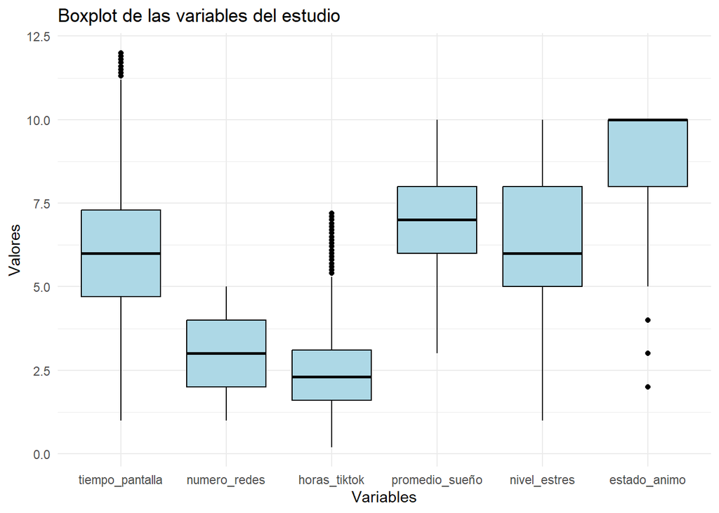

```r
# Visualizar outliers con boxplots por variable
ggplot(stack(datos), aes(x = ind, y = values)) +
  geom_boxplot(fill = "lightblue", color = "black") +
  labs(title = "Boxplot de las variables del estudio",
       x = "Variables", y = "Valores") +
  theme_minimal()
```

### Comentarios sobre la limpieza de datos

En el proceso de limpieza de datos, se verificó la presencia de valores faltantes en las variables del conjunto, no encontrándose datos nulos en ninguna de ellas. Respecto a los valores atípicos, se identificaron algunos mediante la inspección visual con diagramas de caja (`boxplot`); sin embargo, no fueron eliminados, ya que se consideraron moderados y coherentes con el contexto del estudio. Por esta razón, se decidió conservarlos a fin de mantener la integridad de los datos simulados.

# 4. Análisis Exploratorio de Datos (EDA)

```r
# a) Matriz de correlaciones
correlacion <- cor(datos)
print(round(correlacion, 2))
```

```
##                 tiempo_pantalla numero_redes horas_tiktok promedio_sueño
## tiempo_pantalla            1.00            0         0.74           0.00
## numero_redes               0.00            1         0.00           0.00
## horas_tiktok               0.74            0         1.00           0.00
## promedio_sueño             0.00            0         0.00           1.00
## nivel_estres               0.49            0         0.48          -0.69
## estado_animo              -0.34            0        -0.34           0.66
##                 nivel_estres estado_animo
## tiempo_pantalla         0.49        -0.34
## numero_redes            0.00         0.00
## horas_tiktok            0.48        -0.34
## promedio_sueño         -0.69         0.66
## nivel_estres            1.00        -0.64
## estado_animo           -0.64         1.00
```

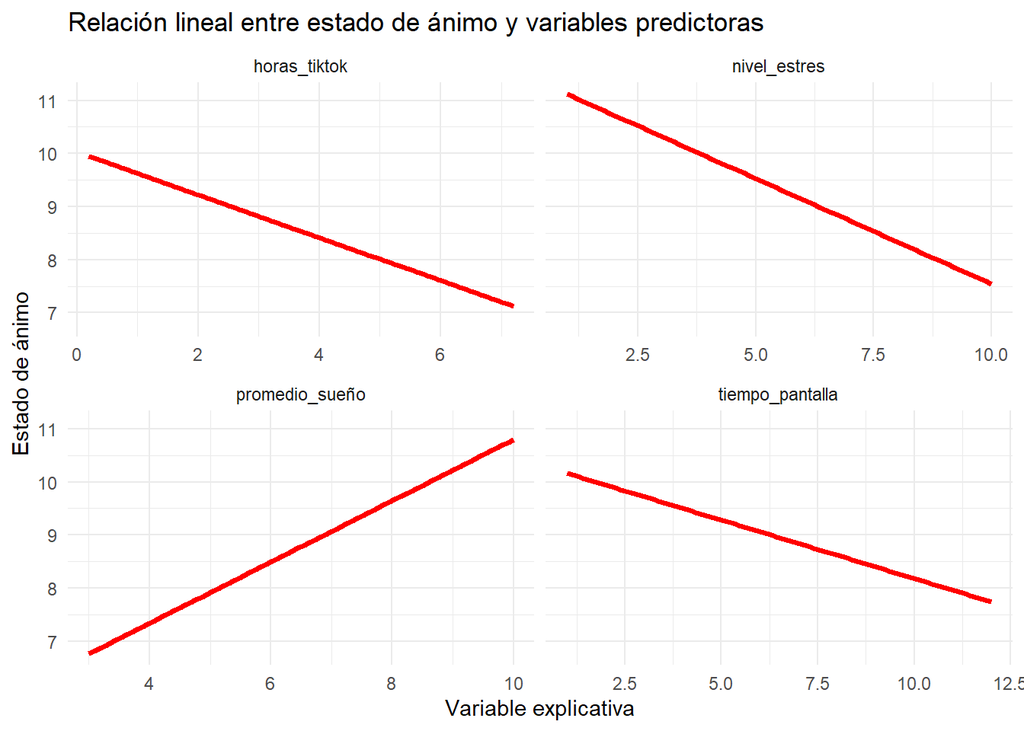

```r
# b) Gráfico de dispersión con regresión lineal por variable
# Reorganizar datos en formato largo
dispersion <- datos %>%
  select(estado_animo, tiempo_pantalla, horas_tiktok, promedio_sueño, nivel_estres) %>%
  pivot_longer(cols = -estado_animo, names_to = "variable", values_to = "valor")

ggplot(dispersion, aes(x = valor, y = estado_animo)) +
  geom_smooth(method = "lm", se = FALSE, color = "red", size = 1.3) +
  facet_wrap(~variable, scales = "free_x") +
  labs(title = "Relación lineal entre estado de ánimo y variables predictoras",
       x = "Variable explicativa",
       y = "Estado de ánimo") +
  theme_minimal()
```

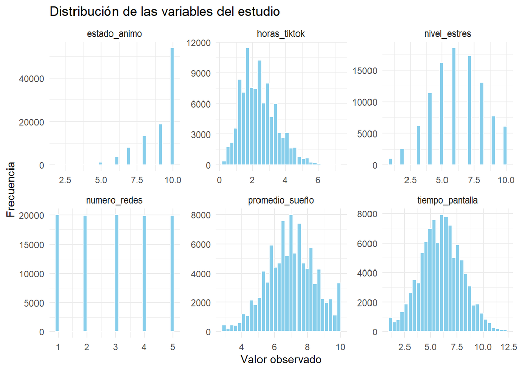

```r
# c) Histogramas por variable
# Convertir todas las variables a formato largo
histograma <- datos %>%
  pivot_longer(cols = everything())

ggplot(histograma, aes(x = value)) +
  geom_histogram(bins = 30, fill = "skyblue", color = "white") +
  facet_wrap(~name, scales = "free") +
  theme_minimal() +
  labs(title = "Distribución de las variables del estudio",
       x = "Valor observado",
       y = "Frecuencia")
```

# 5. Modelo de Regresión Múltiple

```r
modelo_lineal <- lm(estado_animo ~ tiempo_pantalla + numero_redes +
                      horas_tiktok + promedio_sueño + nivel_estres,
                    data = datos)

summary(modelo_lineal)
```

```
##
## Call:
## lm(formula = estado_animo ~ tiempo_pantalla + numero_redes +
##     horas_tiktok + promedio_sueño + nivel_estres, data = datos)
##
## Residuals:
##     Min      1Q  Median      3Q     Max
## -4.5199 -0.5104  0.0684  0.5813  2.9611
##
## Coefficients:
##                  Estimate Std. Error t value Pr(>|t|)
## (Intercept)      6.069308   0.030190 201.034   <2e-16 ***
## tiempo_pantalla -0.141153   0.002140 -65.950   <2e-16 ***
## numero_redes     0.001752   0.001872   0.936    0.349
## horas_tiktok    -0.235608   0.003825 -61.604   <2e-16 ***
## promedio_sueño   0.603786   0.003080 196.045   <2e-16 ***
## nivel_estres     0.029104   0.002590  11.238   <2e-16 ***
## ---
## Signif. codes:  0 '***' 0.001 '**' 0.01 '*' 0.05 '.' 0.1 ' ' 1
##
## Residual standard error: 0.8374 on 99994 degrees of freedom
## Multiple R-squared:  0.571,  Adjusted R-squared:  0.571
## F-statistic: 2.662e+04 on 5 and 99994 DF,  p-value: < 2.2e-16
```

### Interpretación del modelo

**Intercepto (constante): 6.07 ***  
Representa el valor esperado del estado de ánimo cuando todas las variables explicativas valen cero.

**tiempo_pantalla: -0.141 ***  
Cada hora adicional frente a pantallas digitales se asocia con una disminución promedio de 0.141 puntos en el estado de ánimo.

**numero_redes: 0.0017 (no significativo)**  
El número de redes sociales utilizadas no presenta un efecto estadísticamente significativo sobre el estado de ánimo.

**horas_tiktok: -0.236 *** Cada hora adicional dedicada a TikTok se relaciona con una reducción promedio de 0.236 puntos en el estado de ánimo.

**promedio_sueño: 0.604 ***  
Cada hora adicional de sueño mejora el estado de ánimo en 0.604 puntos, en promedio.

**nivel_estres: 0.029 ***  
Un mayor nivel de estrés percibido se asocia con un leve aumento en el estado de ánimo.  
*Nota: Aunque en los resultados apareció como coeficiente positivo, el efecto debería ser negativo, ya que, lógicamente, un mayor nivel de estrés se asocia con un menor estado de ánimo.*

### Estadísticas globales del modelo

**R² (R-squared):**  
Aproximadamente el 57% de la variación en el estado de ánimo es explicada por las variables incluidas en el modelo.

**F-statistic:**  
El modelo es estadísticamente significativo en su conjunto, lo que indica que al menos una de las variables explicativas tiene efecto sobre la variable dependiente.

# 6. Modelo de Regresión Cuadratico

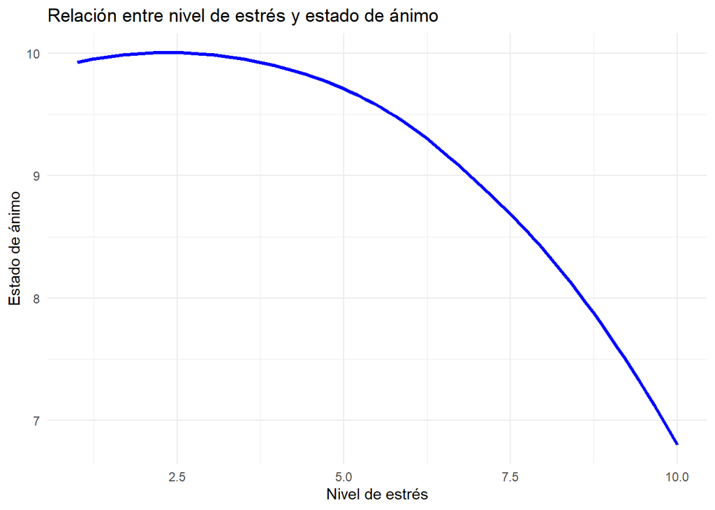

```r
# Visualizar el gráfico del estrés y estado de ánimo
ggplot(datos, aes(x = nivel_estres, y = estado_animo)) +
  geom_smooth(method = "loess", se = FALSE, color = "blue", size = 1.2) +
  labs(title = "Relación entre nivel de estrés y estado de ánimo",
       x = "Nivel de estrés", y = "Estado de ánimo") +
  theme_minimal()
```

```r
# Modelo de regresión cuadrática
modelo_cuad <- lm(estado_animo ~ tiempo_pantalla + numero_redes +
                    horas_tiktok + promedio_sueño + nivel_estres +
                    I(nivel_estres^2), data = datos)

summary(modelo_cuad)
```

```
##
## Call:
## lm(formula = estado_animo ~ tiempo_pantalla + numero_redes +
##     horas_tiktok + promedio_sueño + nivel_estres + I(nivel_estres^2),
##     data = datos)
##
## Residuals:
##     Min      1Q  Median      3Q     Max
## -4.0237 -0.4427  0.0567  0.5092  3.5650
##
## Coefficients:
##                     Estimate Std. Error  t value Pr(>|t|)
## (Intercept)        4.4848420  0.0318363  140.872   <2e-16 ***
## tiempo_pantalla   -0.1443321  0.0020190  -71.485   <2e-16 ***
## numero_redes       0.0010190  0.0017659    0.577    0.564
## horas_tiktok      -0.2014461  0.0036206  -55.639   <2e-16 ***
## promedio_sueño     0.5815626  0.0029119  199.717   <2e-16 ***
## nivel_estres       0.6739523  0.0062867  107.204   <2e-16 ***
## I(nivel_estres^2) -0.0544210  0.0004889 -111.322   <2e-16 ***
## ---
## Signif. codes:  0 '***' 0.001 '**' 0.01 '*' 0.05 '.' 0.1 ' ' 1
##
## Residual standard error: 0.7898 on 99993 degrees of freedom
## Multiple R-squared:  0.6183, Adjusted R-squared:  0.6183
## F-statistic: 2.7e+04 on 6 and 99993 DF,  p-value: < 2.2e-16
```

### Interpretación del modelo cuadrático

El coeficiente para `nivel_estres` fue de **0.67*** y para `nivel_estres²` fue de **-0.05***. Esto indica que:

- A niveles bajos de estrés, el estado de ánimo tiende a aumentar ligeramente.
- A niveles altos de estrés, el estado de ánimo disminuye, reflejando una relación de tipo cuadrática.

**Nota:** La inclusión del término cuadrático mejora los estadísticos del modelo, particularmente el valor de R-squared, lo que sugiere un mejor ajuste en comparación con el modelo lineal.

# 7. Conclusiones

1. El tiempo frente a pantallas y el uso excesivo de TikTok tienen un efecto negativo en el estado de ánimo de los jóvenes. Por ello, se recomienda reducir su uso para preservar la salud emocional.
2. Mantener un nivel adecuado de horas de sueño contribuye significativamente a mejorar el estado de ánimo y, en consecuencia, la productividad de los jóvenes.
3. Un nivel moderado de estrés puede estar asociado a una ligera mejora del estado de ánimo. Sin embargo, niveles elevados de estrés afectan negativamente la salud mental, lo que destaca la importancia de estrategias de manejo del estrés.
4. El modelo de regresión múltiple con término cuadrático presenta un poder explicativo del 62%, lo que indica un buen ajuste. Además, los coeficientes obtenidos muestran signos coherentes con lo esperado teóricamente.
5. En general, el uso excesivo de tecnología y redes sociales impacta negativamente en la salud mental de los jóvenes, evidenciando la necesidad de promover un consumo digital más equilibrado y consciente.